# Parameterised Reporting of Predicted Antimicrobial Resistance Rates using Quarto

# – Further information –

## Kudos

Jadey N Ryan gave an excellent talk on creating parameterised reports at this year’s posit::conf(2023)

[tinyurl.com/quarto-params](https://jadeynryan.github.io/2023_posit-parameterized-quarto/)

github.com/jadeynryan

Megan Hall wrote an excellent blog post on creating parameterised reports (2022)

https://meghan.rbind.io/blog/quarto-pdfs

https://github.com/meghall06

## Reprex

Producing parameterised reports using the {nycflights13} dataset

github.com/send2dan/public

[figure not shown]

# – Project setup –

## Requirements

1. Quarto script with YAML specifying parameter(s)
2. Code to wrangle dataset into “params”
3. +/- Specification of parameter(s) in body of report
4. +/- R script to execute/render parameterised reports using Quarto
5. +/- Inline code

## YAML

```r
---
title: "Parameterised report"                         # Metadata
subtitle: "Analysis of the {nycflights13} dataset"
author: "Daniel Weiand"
format:                             # Set format types
  html:
  docx:
  revealjs:
params:                             # Set default parameter key-value pairs
  origin: "NA"
  dest: "NA"
  month: "NA"
---

Report content goes here.           # Write content
```

## Wrangling data into “params”

For each parameter, wrangle dataset into “params” **after** loading required packages and raw data **before** any additional data wrangling steps.

```r
library(nycflights13)                                       # load packages and data
flights <- nycflights13::flights

if (!is.na(params$origin) && params$origin != "NA") {       # Param for nycflights13::flights$origin
  flights <- flights[flights$origin == params$origin, ]
}
if (nrow(flights) == 0) {
  stop("Invalid selection. Did you misspell `origin`?")
}

not_cancelled <- flights |>                                 # undertake additional wrangling steps
  filter(!is.na(arr_delay), !is.na(dep_delay))

---
Report content goes here.                                   # Write content
```

## Specification parameters in report

```r
This report focuses on the following parameter(s):

Origin airport: **`r params$origin`**             # Param for flights$origin

Destination airport: **`r params$dest`**          # Param for flights$dest

Month of flight departure: **`r params$month`**   # Param for flights$month
```

## Inline code

Strengthen the narrative of your report by including executable expressions within markdown using `` `r ` ``.

For example, we can use inline code to state the number of observations in our data.

```r
There are `r nrow(flights)` observations in our data.
```

**There are 336776 observations in our data.**

# – Rendering reports –

## Three options for rendering reports

1. YAML
2. Terminal
3. quarto::quarto_render() function

## Rendering reports using YAML

Manually change the parameter values in the header YAML of your .qmd file and hit Render.

```r
params:
  dest: "NA"
  origin: "JFK"             # JFK airport specified in YAML
  month: "NA"
```

## Rendering reports using the terminal

Use the terminal to specify the parameter(s) you want to use.

```r
quarto render
```

```r
quarto render parameterised_report.qmd
```

```r
quarto render parameterised_report.qmd -P
```

```r
quarto render parameterised_report.qmd -P origin:JFK      # JFK specified as origin airport
```

## Rendering reports using quarto::quarto_render()

Leverage the quarto::quarto_render() function in R to automatically create reports for each parameter subcategory and name each file as specified.

```r
runparams <- function(origin) {             # create function
  quarto::quarto_render(
    "parameterised_report.qmd",                       # Specify .qmd file name
    output_format = "html",                           # Specify output format
    execute_params = list(origin = origin),           # Specify parameter of interest
    output_file = glue::glue("report_{origin}.html")  # Specify (parameterised) file name
  )
}

runparams(origin = "JFK")                 # code to run a single report using function

params_origin <- unique(flights$origin)             # Or execute code with purrr:map() function
purrr::map(params_origin, runparams)
```

# – Apply theory in practice –

**Aim**

To model predicted drug resistance rates using the [AMR](https://msberends.github.io/AMR/articles/AMR.html) package for [R](https://nhsrcommunity.com/installing-r-and-r-studio/).

**Methods**

The LIMS was interrogated to collect data on all culture-positive blood cultures collected between 01 April 2019 and 31 July 2023 .

## The AMR package for R

The [AMR](https://msberends.github.io/AMR/articles/AMR.html) package [1,2] is a free, open-source and independent package for [R](https://nhsrcommunity.com/installing-r-and-r-studio/) [3] that provides a standard for clean and reproducible analysis and prediction of Antimicrobial Resistance (AMR).

Helps to: cleverly de-duplicate data; calculate and visualise historical AMR rates; and predict future AMR rates using regression models.

[figure not shown]

## Other key packages

- The {[NHSRplotthedots](https://github.com/nhs-r-community/NHSRplotthedots/)} package [4] is used to plot time series data and detect special cause variation by applying statistical process control (SPC) rules.
- The {ggsurvfit} and {survival} packages [5–7] are used to conduct survival analyses.

# – Results –

## Totals

Since Q1 2019:

11967 distinct positive **blood cultures**

Collected from 7435 **distinct patients**

Leading to isolation of 13227 **organisms**

## Distinct positive blood cultures per month

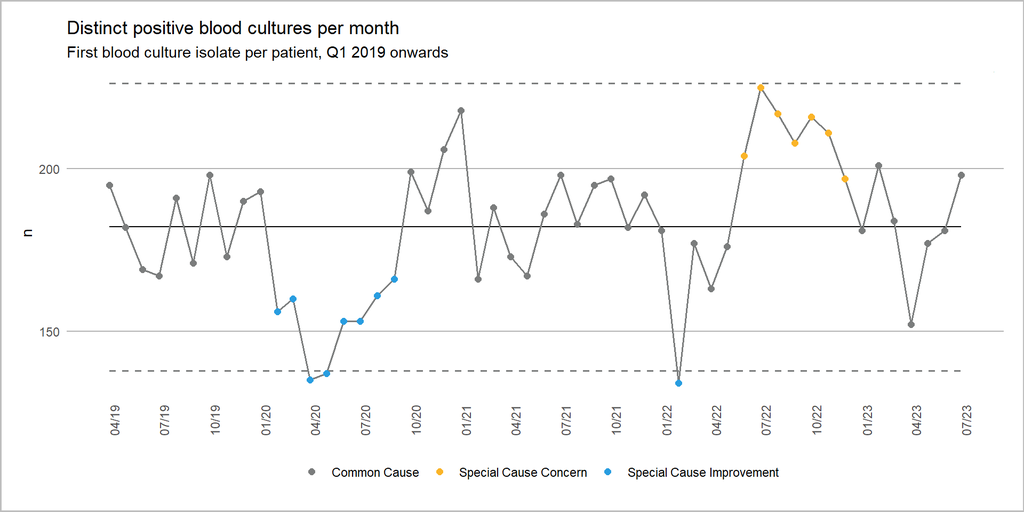

## Survival analysis

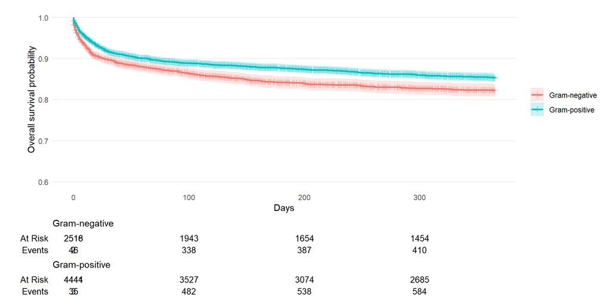

| **Characteristic** | **90-day survival (95% CI)** | **180-day survival (95% CI)** | **365-day survival (95% CI)** |
| --- | --- | --- | --- |
| Overall | 88% (87%, 89%) | 86% (85%, 87%) | 84% (83%, 85%) |
| Gram stain result |  |  |  |
| Gram-negative | 87% (86%, 88%) | 84% (83%, 86%) | 82% (81%, 84%) |
| Gram-positive | 89% (88%, 90%) | 88% (87%, 89%) | 85% (84%, 86%) |
| Organism isolated |  |  |  |
| E. coli | 88% (86%, 90%) | 86% (84%, 88%) | 84% (82%, 86%) |
| K. pneumoniae | 85% (82%, 88%) | 82% (79%, 86%) | 79% (75%, 83%) |
| Other | 89% (88%, 90%) | 87% (86%, 88%) | 85% (84%, 86%) |
| P. aeruginosa | 83% (77%, 89%) | 80% (74%, 86%) | 79% (74%, 86%) |
| S. aureus | 85% (82%, 88%) | 83% (80%, 87%) | 81% (77%, 84%) |

## Organism-specific historical AMR rates

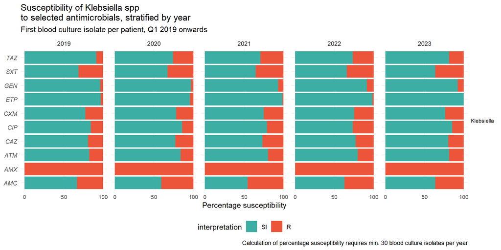

## Organism-specific predicted AMR rates

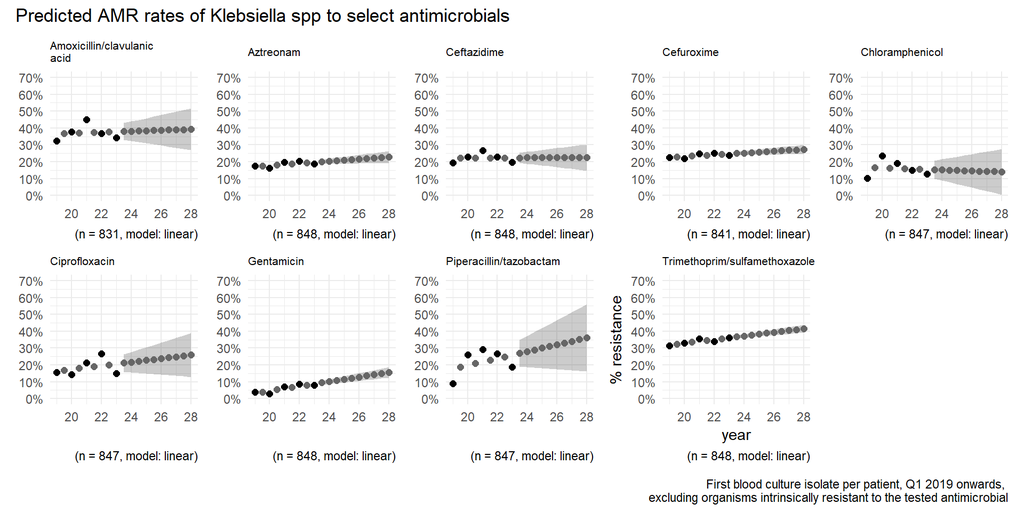

# – Parameterised results –

## By hospital

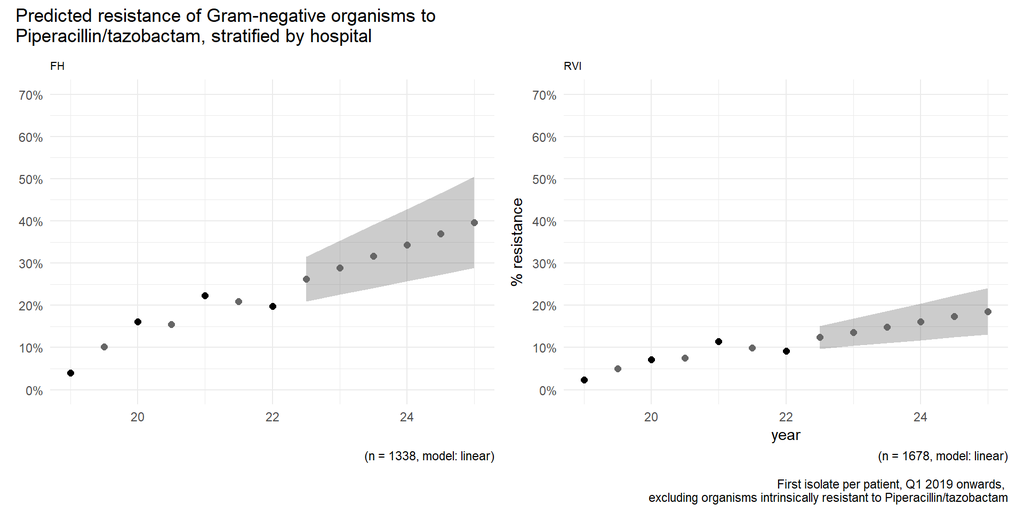

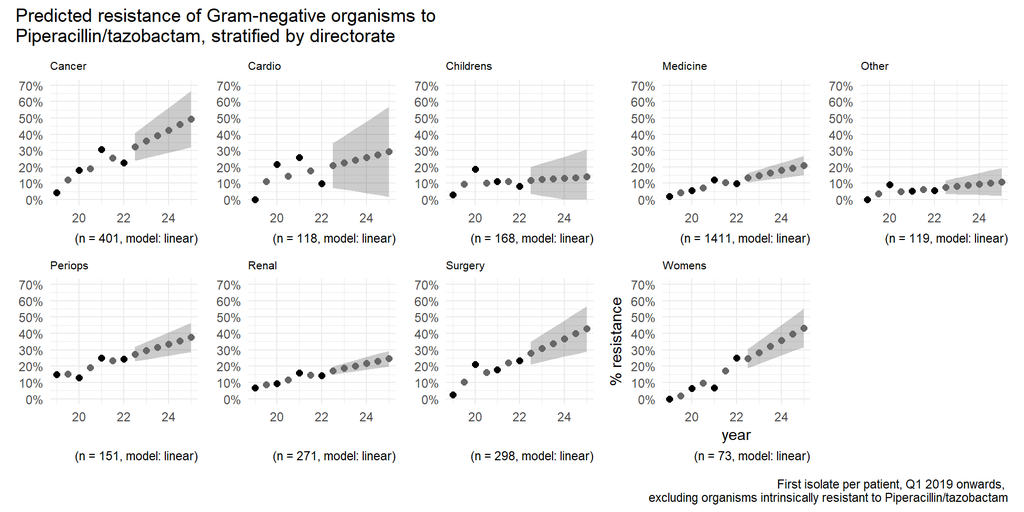

## By ward

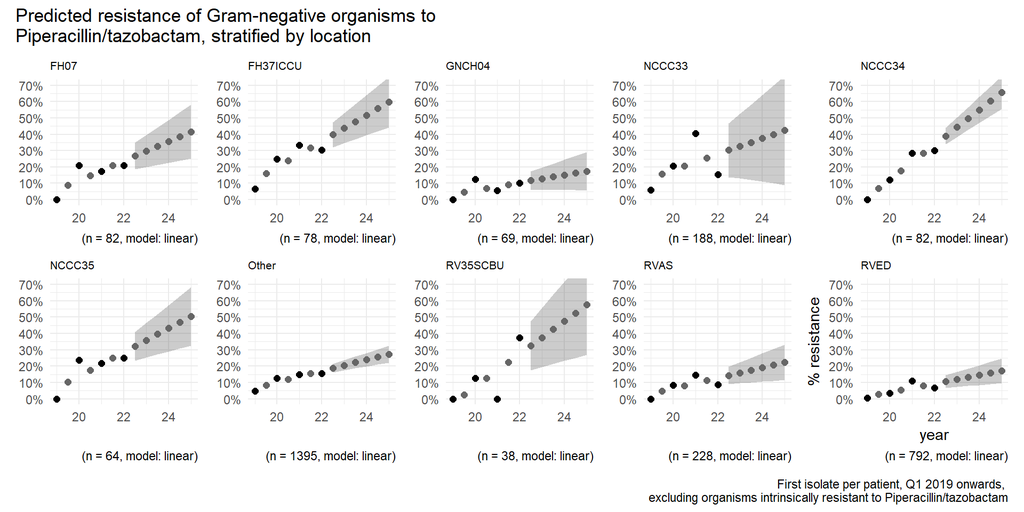

## By age group

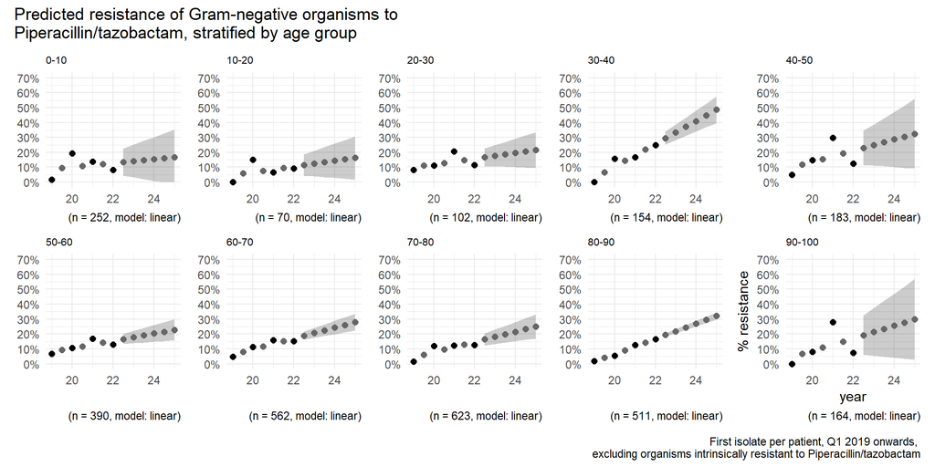

## Output

[figure not shown]

## Sharing the results

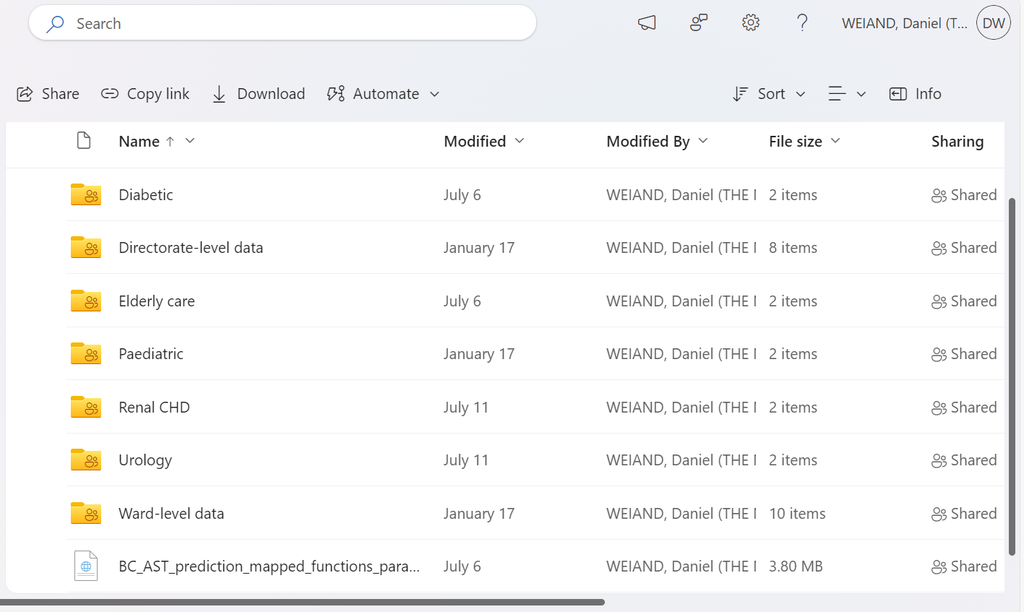

## Benefits of parameterised reporting of AMR rates

Informs clinical decision-making

[figure not shown]

Helps target (limited) infection prevention and control resources

[figure not shown]

Assists with updating of antimicrobial guidelines

[figure not shown]

Helps justify investment in antimicrobial stewardship

[figure not shown]

# – Thanks for listening –

## Further information

Daniel Weiand, Consultant medical microbiologist

Newcastle upon Tyne Hospitals NHS Foundation Trust

Email: dweiand@nhs.net

NHS-R community blog: https://nhsrcommunity.com/author/daniel-weiand/

send2dan

github.com/send2dan/public

[figure not shown]

[figure not shown]

## References

1

Berends MS, Luz CF, Friedrich AW, *et al.* AMR: An R package for working with antimicrobial resistance data. *Journal of Statistical Software* 2022;**104**:1–31. doi:10.18637/jss.v104.i03

2

Berends MS, Luz CF, Souverein D, *et al.* *AMR: Antimicrobial resistance data analysis*. 2023. https://CRAN.R-project.org/package=AMR

3

R Core Team. *R: A language and environment for statistical computing*. Vienna, Austria: : R Foundation for Statistical Computing 2022. https://www.R-project.org/

4

Reading C, Wellesley-Miller S, Turner Z, *et al.* *NHSRplotthedots: Draw XmR charts for NHSE/i making data count programme*. 2021. https://nhs-r-community.github.io/NHSRplotthedots/

5

Sjoberg DD, Baillie M, Fruechtenicht C, *et al.* *Ggsurvfit: Flexible time-to-event figures*. 2023. https://CRAN.R-project.org/package=ggsurvfit

6

Therneau TM. *Survival: Survival analysis*. 2022. https://github.com/therneau/survival

7

Terry M. Therneau, Patricia M. Grambsch. *Modeling survival data: Extending the Cox model*. New York: : Springer 2000.

[figure not shown]

github.com/send2dan [@send2dan](https://twitter.com/send2dan)